# Predicting Emmployee Attrition

H MacGinty

23 June 2023

### Abstract

This paper investigates employee attributes and attrition. Random forests are used to build a model to predict employee attrition based on key attributes, such as education, pay, gender, and age, among others.

# Introduction

Losing employees can be costly for businesses. Predicting attrition and its key determinants or attributes can help estimate future employee turnover and attempt to reduce it.

# Exploratory Data Analaysis

## 0.1 Graphical analysis

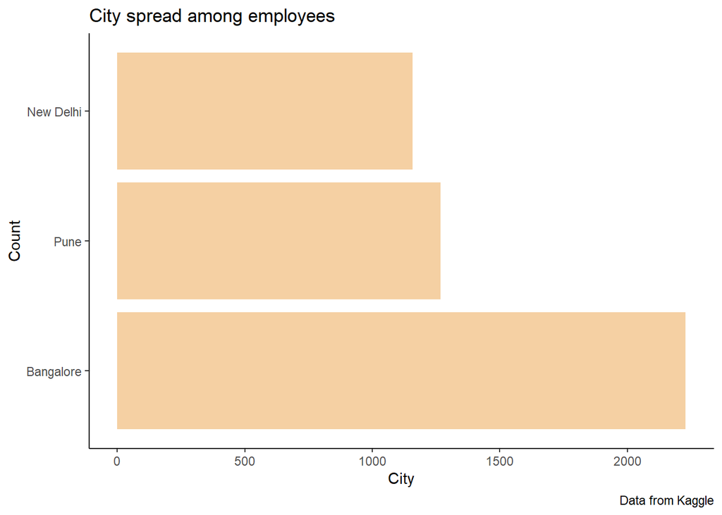

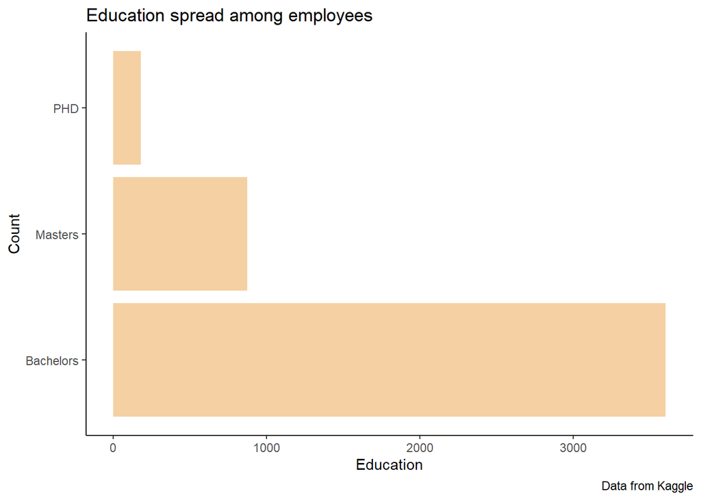

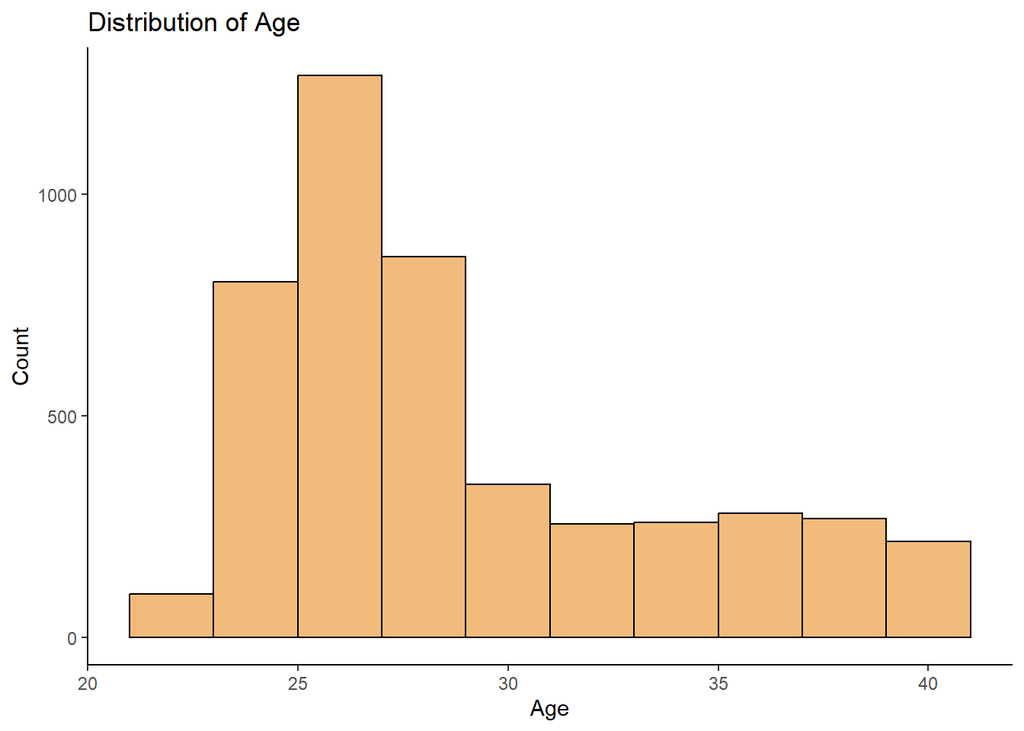

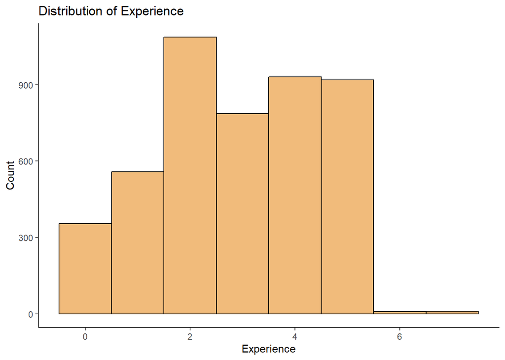

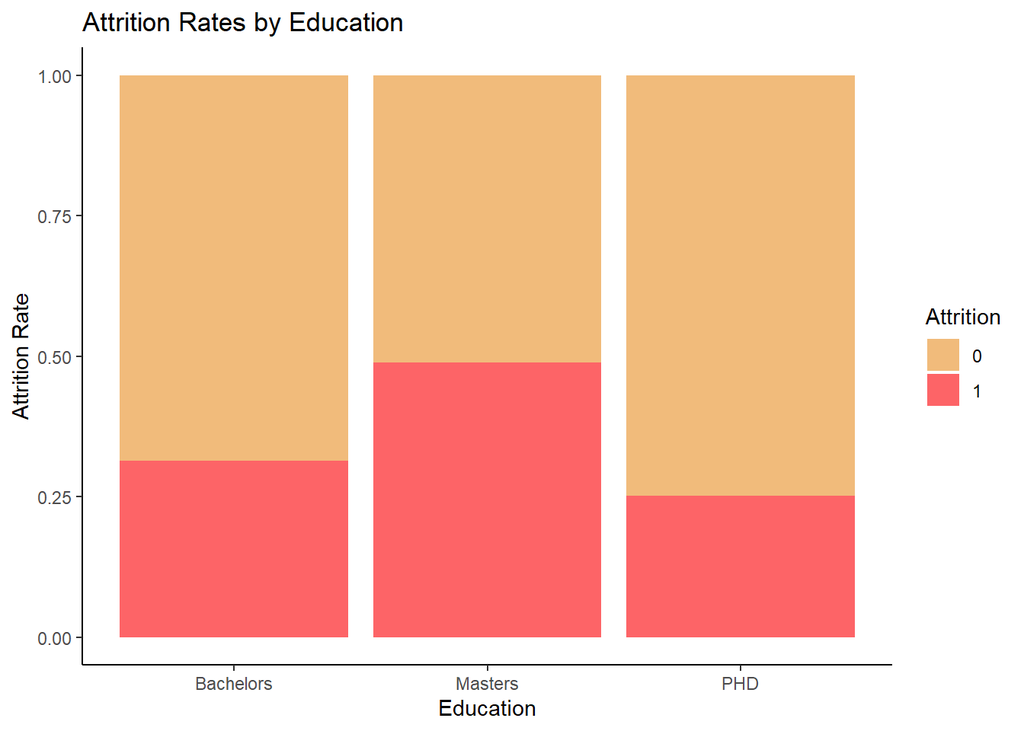

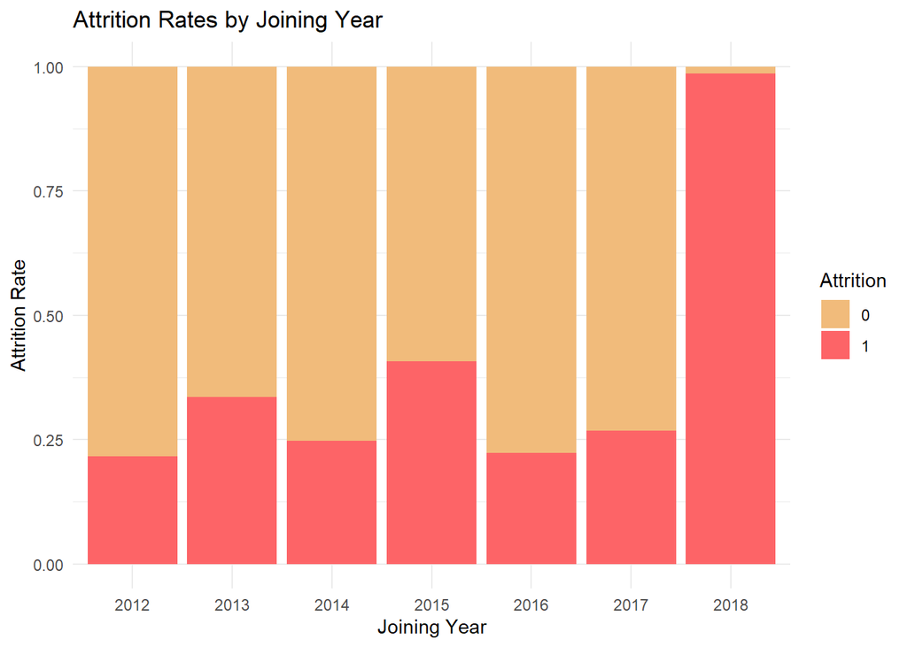

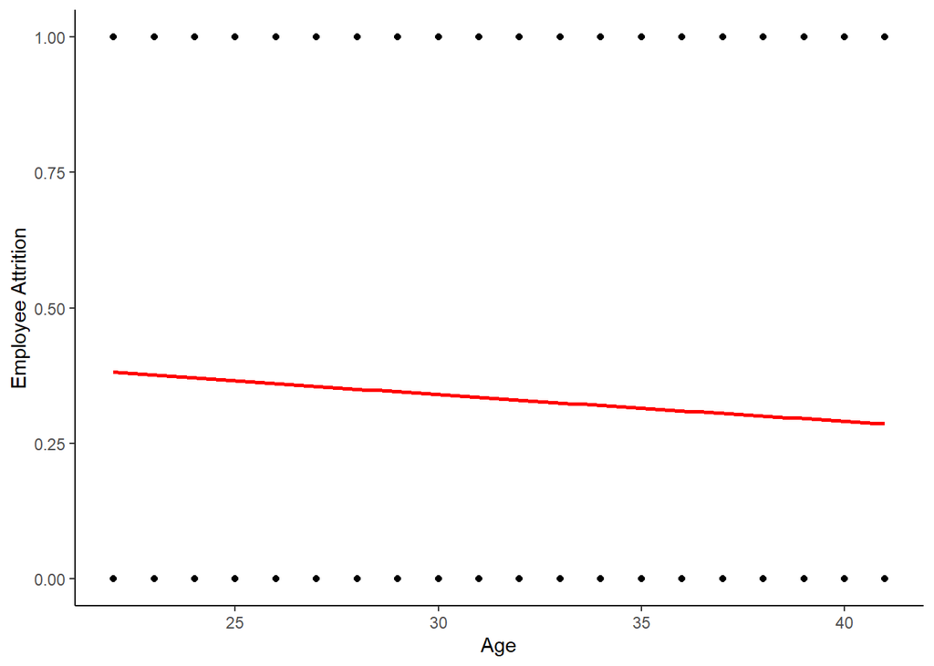

Table 1: Attrition Rate Table by Attribute

|  | Variable | Category | Attrition.Rate |
| --- | --- | --- | --- |
| 1 | Education | Bachelors | 31.35240 |
| 2 | Education | Masters | 48.79725 |
| 3 | Education | PHD | 25.13966 |
| 4 | City | Bangalore | 26.70557 |
| 5 | City | New Delhi | 31.63353 |
| 6 | City | Pune | 50.39432 |
| 7 | Gender | Female | 47.14667 |
| 8 | Gender | Male | 25.77394 |
| 9 | Year | 2012 | 21.62698 |
| 10 | Year | 2013 | 33.48281 |
| 11 | Year | 2014 | 24.74964 |
| 12 | Year | 2015 | 40.71703 |
| 13 | Year | 2016 | 22.28571 |
| 14 | Year | 2017 | 26.80505 |
| 15 | Year | 2018 | 98.63760 |
| 16 | Pay | 1 | 36.62551 |
| 17 | Pay | 2 | 59.91285 |
| 18 | Pay | 3 | 27.52005 |

# Pre-processing

## Feature and Target Engineering

Since my predictor variable (Leave or Not) is binary, there is no need for target engineering.

Regarding feature engineering, most of the features are categorical. Gender and whether a person benched or not (removed themselves from projects in the lst month) are transformed into dummies.

Since age is numeric and random forests are able to handle both numeric and categorical variables, it is not altered.

# Bias-Variance Trade-off

It is also important to consider the bias-variance trade-off. Prediction errors are generally a result of either bias or variance. In general, decreasing bias will almost always lead to greater variance. Bias is the difference between the expected prediction and the correct value (linear models have high levels of bias).

Variance error is the variability of a model prediction for a given data point. Some models can potentially overfit the training data, resulting in accurate results against the training data but typically poor results against the test data. In other words, the model does not generalise well.

We can adjust the model hyperparameters to achieve the best mix of bias and variance.

# Multiple Logistic Regression

Table 2: Model Accuracy in Logistic Regressions

|  | Min. | 1st Qu. | Median | Mean | 3rd Qu. | Max. | NA’s |
| --- | --- | --- | --- | --- | --- | --- | --- |
| model1 | 0.6153846 | 0.6584615 | 0.6589854 | 0.6545808 | 0.6595092 | 0.6595092 | 0 |
| model2 | 0.6276923 | 0.6380368 | 0.6447159 | 0.6441513 | 0.6495399 | 0.6615385 | 0 |
| model3 | 0.7116564 | 0.7210723 | 0.7292308 | 0.7276663 | 0.7354294 | 0.7415385 | 0 |

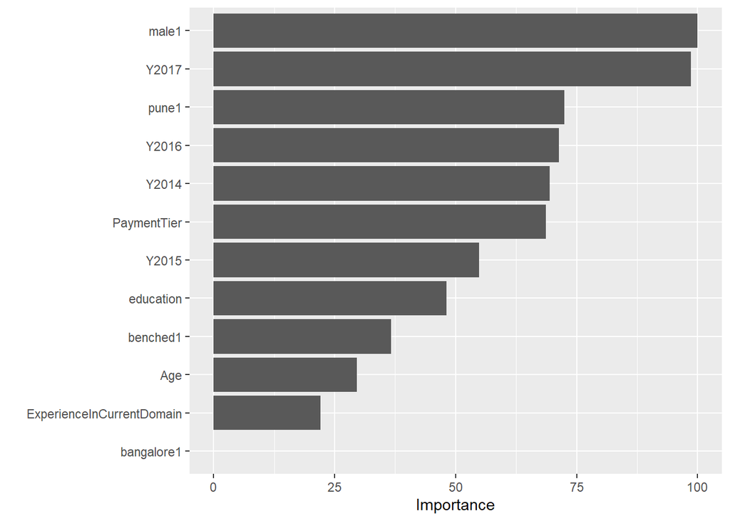

# Random Forests

## Decision tree

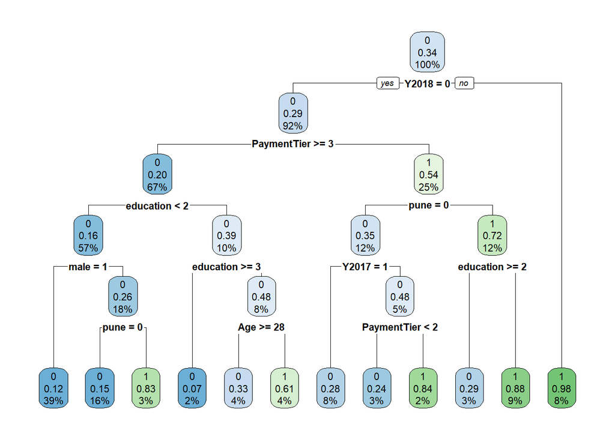

```
## Accuracy: 83.02292 %
```

The issue with bagging is that the trees in bagging are not independent (tree correlation). Random Forests help to reduce tree correlation. It does so by using split-variable randomisation. Number of trees should be 10 times number of feautures, as a rule of thumb.

```
## [1] 0.3902402
```

```
## Ranger prediction
##
## Type:                             Classification
## Sample size:                      1396
## Number of independent variables:  14
```

[output not shown]

[output cut: 24 more lines]

```
## [1] 0.8517192
```

```
## [1] 0.9174312
```

```
## [1] 0.625
```

```
## [1] 0.7434944
```

```
## Area under the curve: 0.7978
```

There are several hyperparamters to consider in this model: the number of trees, the number of features to consider at a given split, the complexity of each tree, the sampling scheme, the splitting rule to use during tree construction.

Node size is the most common method to control tree complexity.

# Appendix